# Features of Instagram reels

## Plot 1

[figure not shown]

## Plot 1 - Decription

The plot is based on Instagram reels and comparing the number of reels that do or do not contain a soundtrack, where there are different reels across a period of 2/3 months (March, April, May). Various methods were used to help achieve this plot, and the reason why I wanted to see if there was a difference of the reels that appeared on my Instagram feed when I completed Project 2 in March/April compared to when I was completing Project 4.

From the plot, the difference between the reels that had a soundtrack vs those that had a soundtrack at the time of Project 2 is mostly similar to the difference between the reels that had a soundtrack vs those that had a soundtrack of when Project 4 was being completed. This was quite interesting because I expected that reels that contained a soundtrack would have a higher proportion, as I felt that reels that have music receive more views, thus resulting in a higher likelihood of appearing on users’ Instagram feeds.

## Plot 2

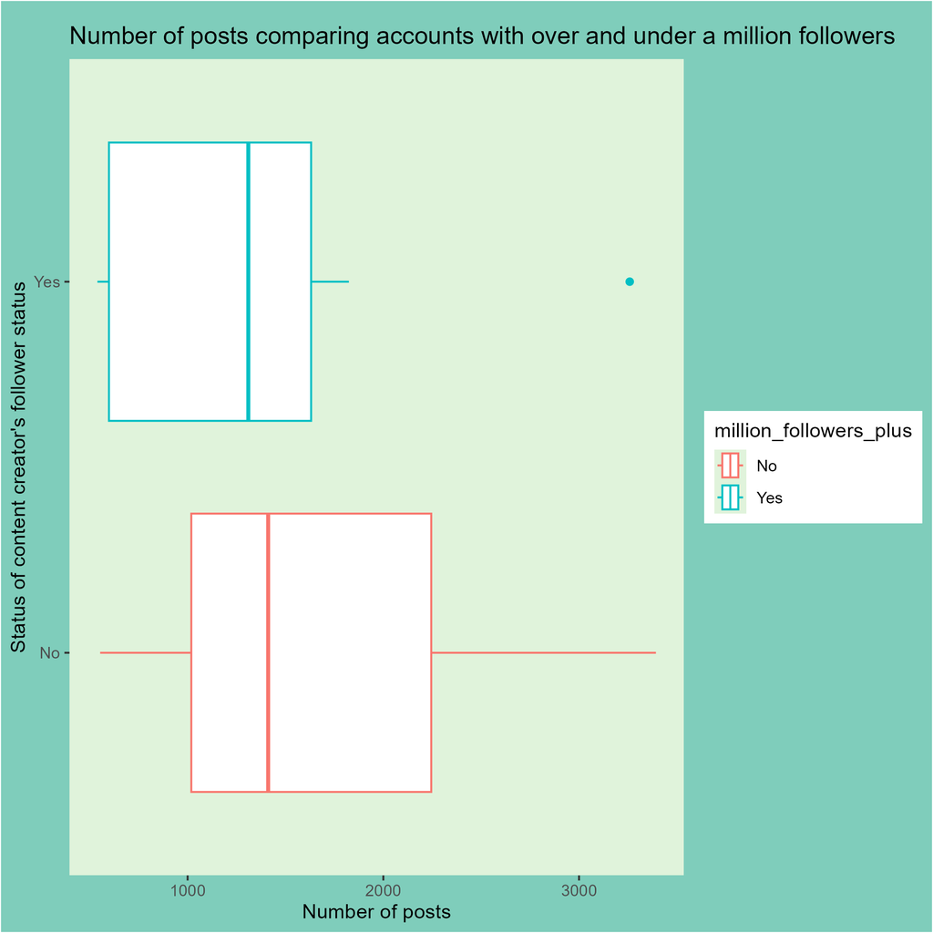

## Plot 2 - Decription

I decided to create a box plot, comparing the number of posts made by the Instagram accounts that had their reels appear on my Instagram feed, and the number of followers (accounts that had over a million followers vs accounts that had under a million followers). I was interested to see if accounts that had a higher number of posts had more than a million followers, but when looking at the plot that’s not the case in this scenario. From the plot, the IQR of the accounts that had less than a million followers is greater than the IQR of the accounts that had more than a million followers, which is quite surprising.

Another thing to note is that the median number of posts between the groups isn’t too far. I filtered the data by only keeping reels that had over 500 posts and less than and equal to 3500 posts, and the reason I did this was because when I looked at the data, I saw that there were reels that had a very low number of posts and reels that had a extremely high number of posts, and I didn’t want that to affect the result of the plot in a significant way. While the output of the plot was surprising, the result could’ve been affected by a difference in proportion (e.g. there could’ve been more reels that had less than a million followers compared to reels that had more than a million followers).

## Plot 3

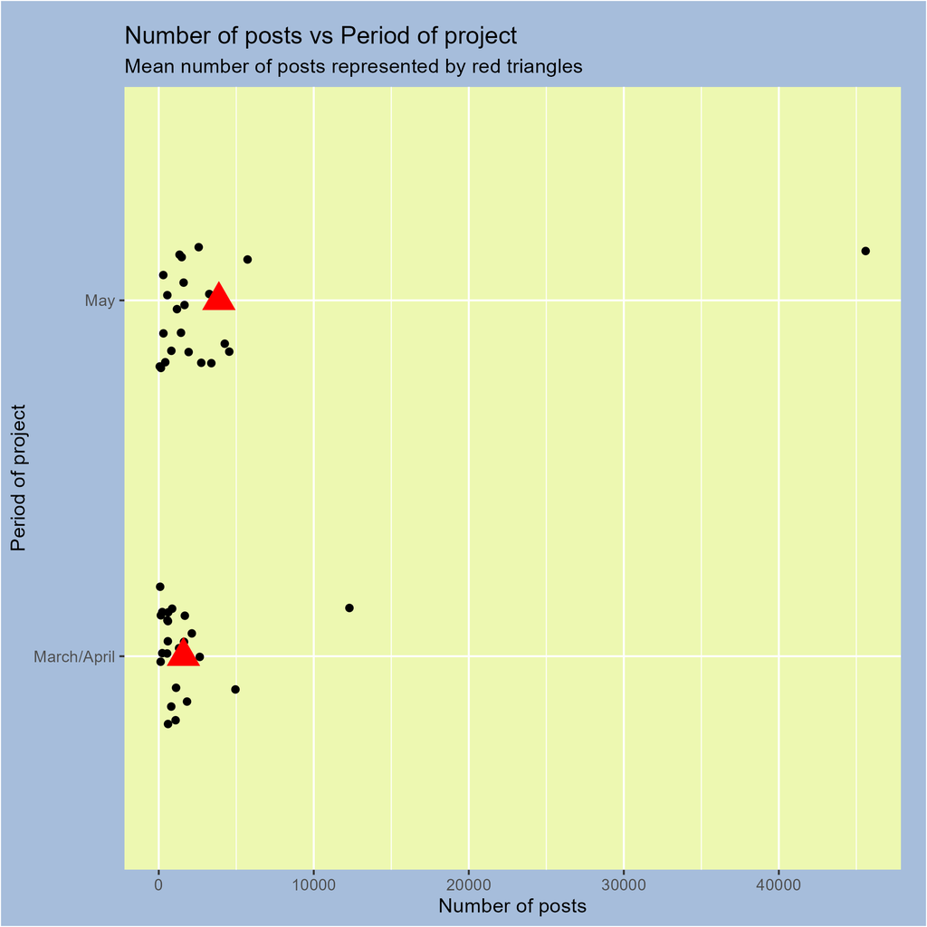